# GAssignment

### Read the data in and load any necessary libraries.

```r
setwd('~/Downloads/Final project/Datasets')
data <- read.csv('statdata2.csv', header = T)

require(ggplot2)
require(reshape2)
require(Biostrings)
require(ggseqlogo)
require(caret)
require(e1071)
require(readxl)
require(sqldf)
require(dplyr)
require(knitr)
```

### Initial data exploration through creation of descriptive graphs

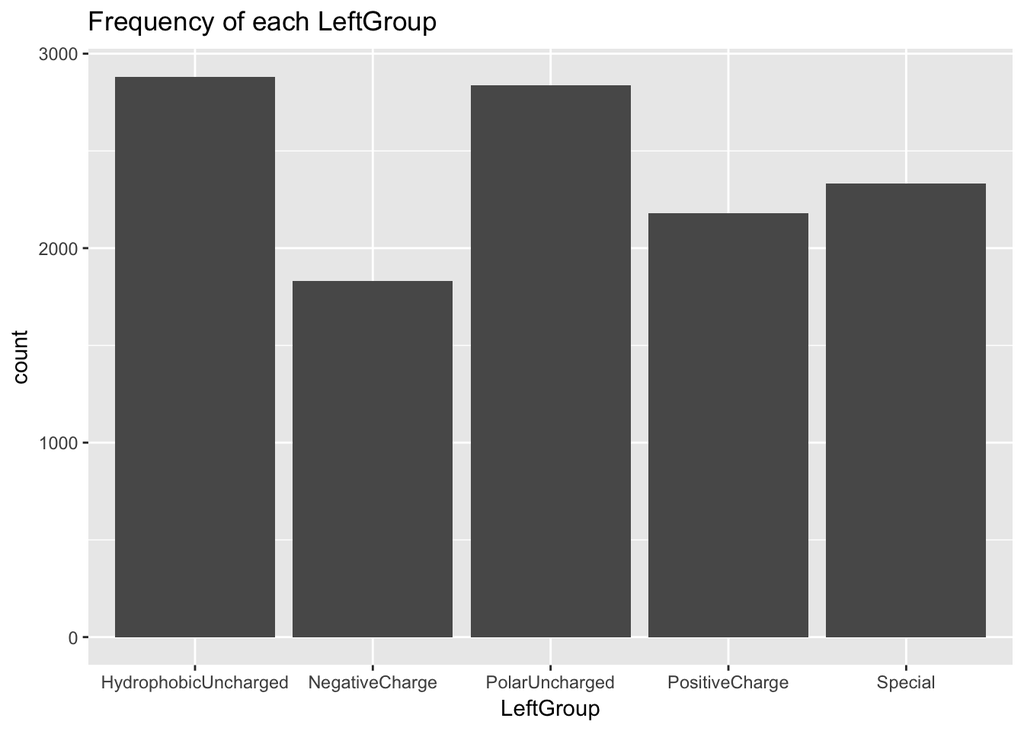

```r
require(ggplot2)

#Overall Frequency plots by groups
##Leftgroup frequency plot
ggplot(data = data, mapping = aes(x = LeftGroup)) + geom_bar(aes(y = ..count..)) + ggtitle('Frequency of each LeftGroup')
```

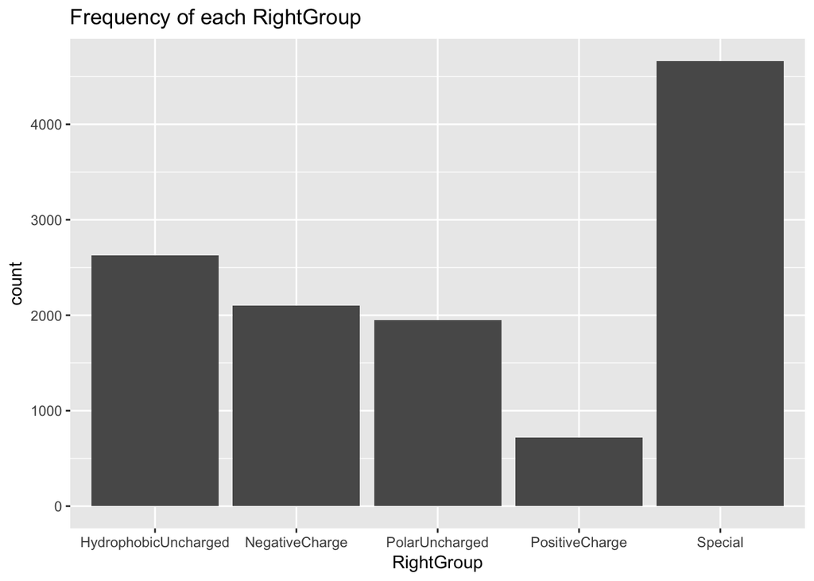

```r
##Rightgroup frequency plot
ggplot(data = data[data$RightGroup!= 'BLANK',], mapping = aes(x = RightGroup)) + geom_bar(aes(y = ..count..)) + ggtitle('Frequency of each RightGroup')
```

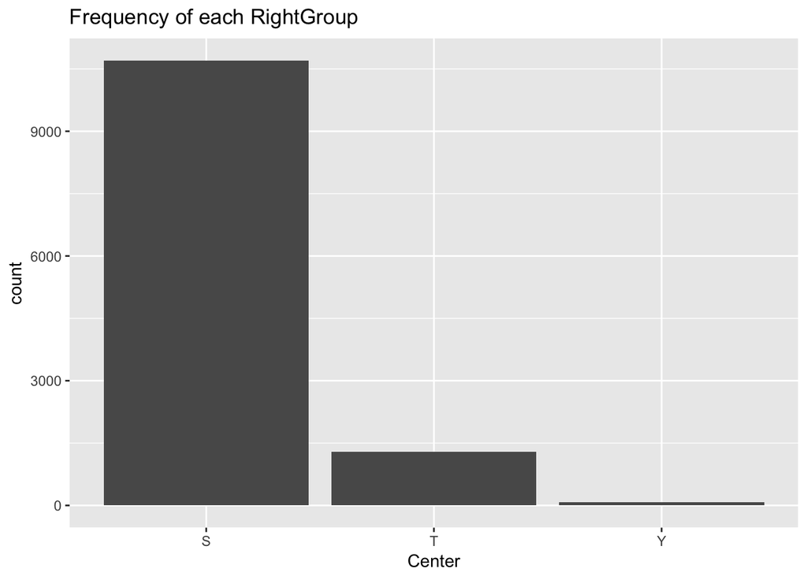

```r
##Centre frequency plot
ggplot(data = data, mapping = aes(x = Center)) + geom_bar(aes(y = ..count..)) + ggtitle('Frequency of each RightGroup')
```

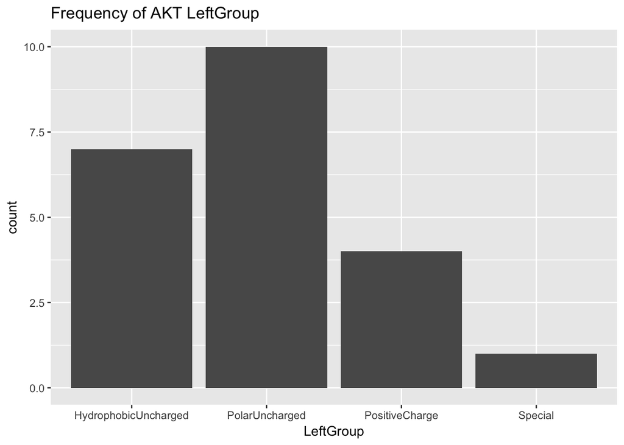

```r
#Frequency plots for AKT
##Left
ggplot(data = data[data$Label == 'AKT',], mapping = aes(x = LeftGroup)) + geom_bar(aes(y = ..count..)) + ggtitle('Frequency of AKT LeftGroup')
```

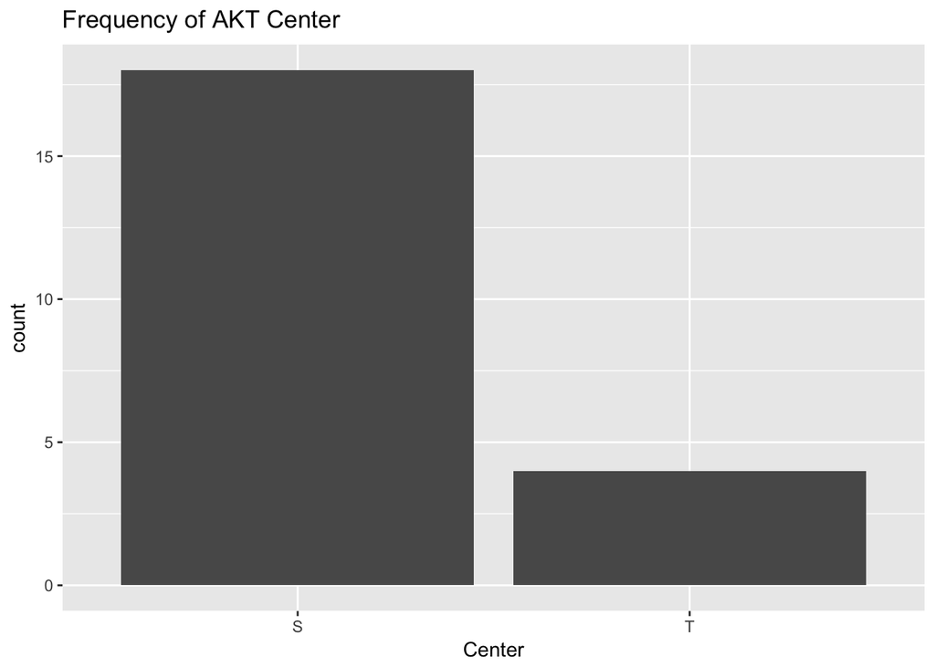

```r
##Center
ggplot(data = data[data$Label == 'AKT',], mapping = aes(x = Center)) + geom_bar(aes(y = ..count..)) + ggtitle('Frequency of AKT Center')
```

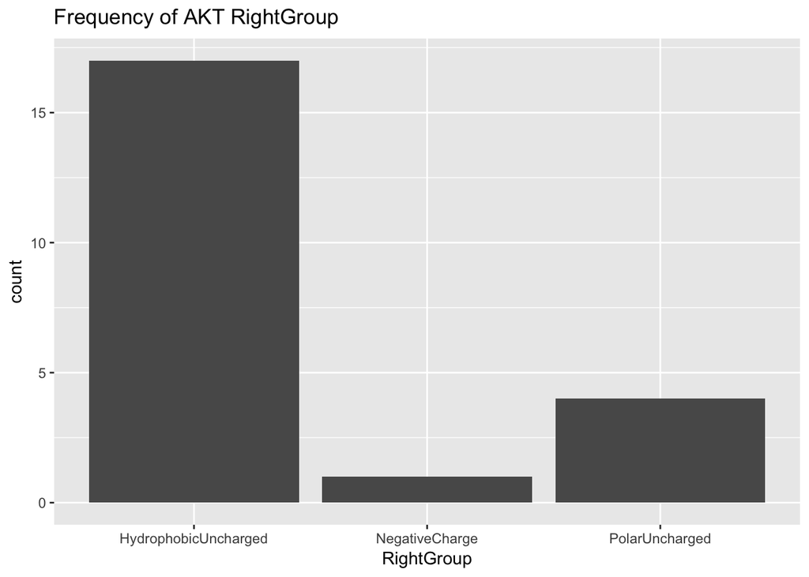

```r
##Right
ggplot(data = data[data$Label == 'AKT',], mapping = aes(x = RightGroup)) + geom_bar(aes(y = ..count..)) + ggtitle('Frequency of AKT RightGroup')
```

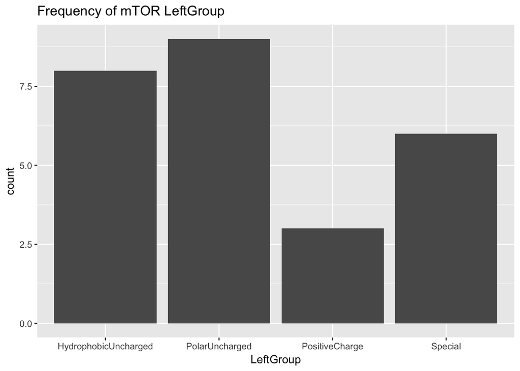

```r
#Frequenct plots for MTOR
##Left
ggplot(data = data[data$Label == 'mTOR',], mapping = aes(x = LeftGroup)) + geom_bar(aes(y = ..count..)) + ggtitle('Frequency of mTOR LeftGroup')
```

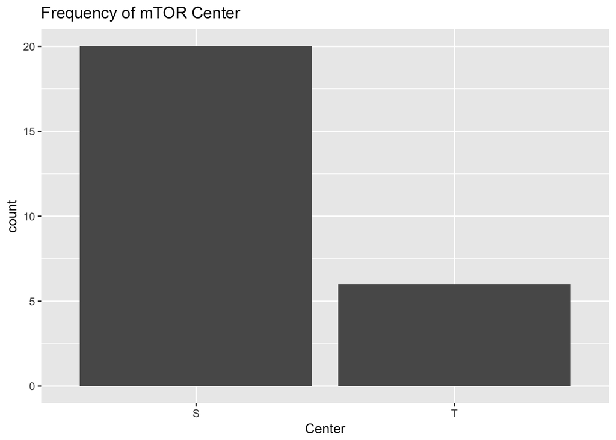

```r
##Center
ggplot(data = data[data$Label == 'mTOR',], mapping = aes(x = Center)) + geom_bar(aes(y = ..count..)) + ggtitle('Frequency of mTOR Center')
```

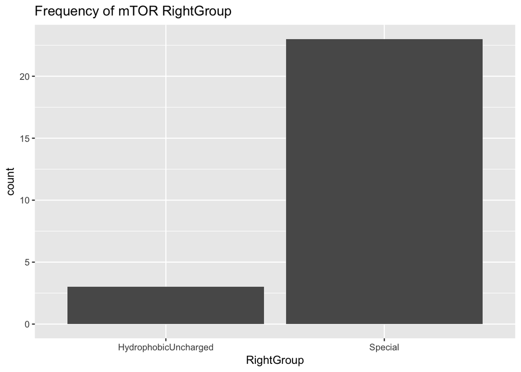

```r
##Right
ggplot(data = data[data$Label == 'mTOR',], mapping = aes(x = RightGroup)) + geom_bar(aes(y = ..count..)) + ggtitle('Frequency of mTOR RightGroup')
```

### Boxplots for AKT and mTOR

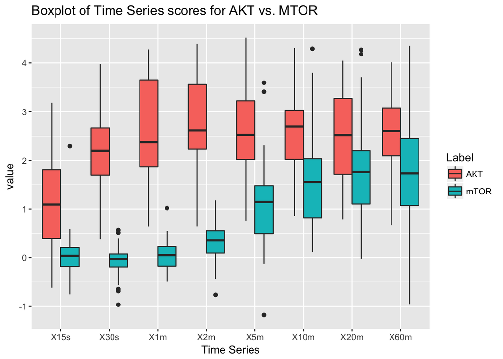

```r
require(ggplot2)
#Data reshaping for time series scores
require(reshape2)
data.t <- data[,c(5,20:27)]
data.mt <- melt(data.t[data.t$Label != 'NULL',], id.var = "Label")

##Boxplots for each time period for AKT VS MTOR
ggplot(data.mt, mapping = aes(x = variable, y=value)) + geom_boxplot(aes(fill=Label)) + xlab('Time Series') + ggtitle('Boxplot of Time Series scores for AKT vs. MTOR')
```

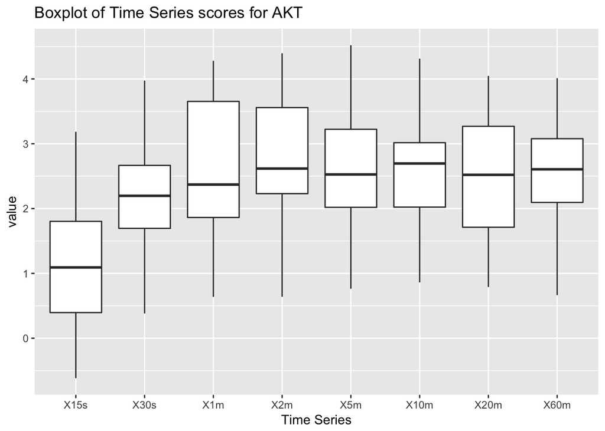

```r
##Separate plots for Akt and MTOR
###AKT
ggplot(data.mt[data.mt$Label == 'AKT',], mapping = aes(x = variable, y=value)) + geom_boxplot() + xlab('Time Series') + ggtitle('Boxplot of Time Series scores for AKT')
```

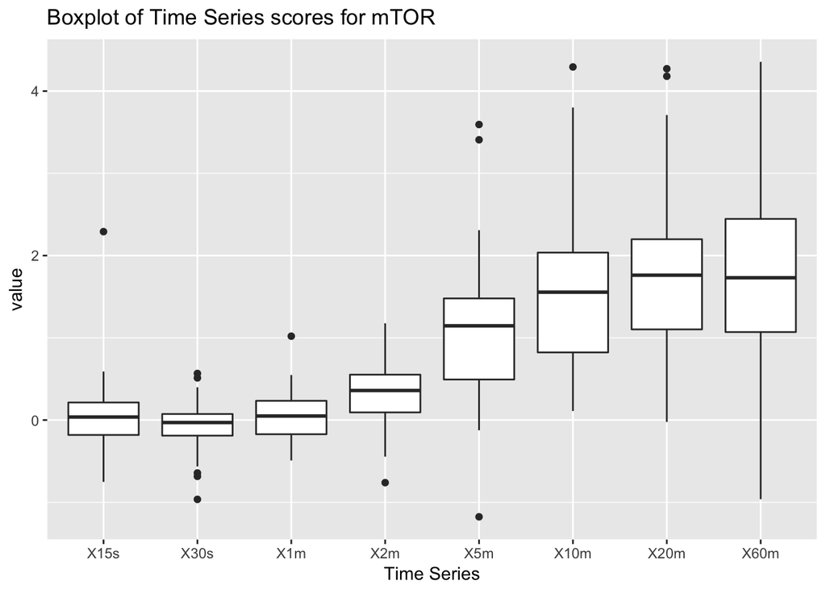

```r
###MTOR
ggplot(data.mt[data.mt$Label == 'mTOR',], mapping = aes(x = variable, y=value)) + geom_boxplot() + xlab('Time Series') + ggtitle('Boxplot of Time Series scores for mTOR')
```

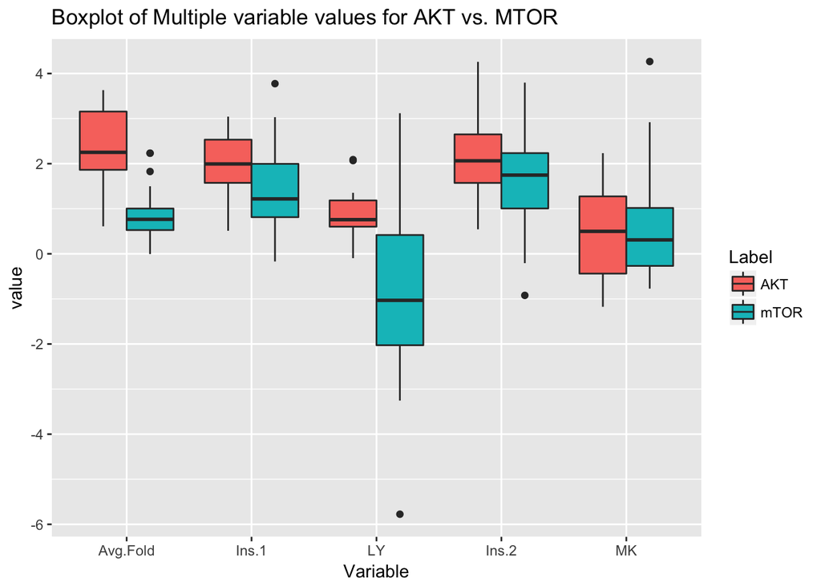

```r
##Fold, Ins, LY, MK Boxplots
data.i <- data[,c(5,18,28:31)]
data.mi <- melt(data.i[data.i$Label != 'NULL',], id.var = "Label")

ggplot(data.mi, mapping = aes(x = variable, y=value)) + geom_boxplot(aes(fill=Label)) + xlab('Variable') + ggtitle('Boxplot of Multiple variable values for AKT vs. MTOR')
```

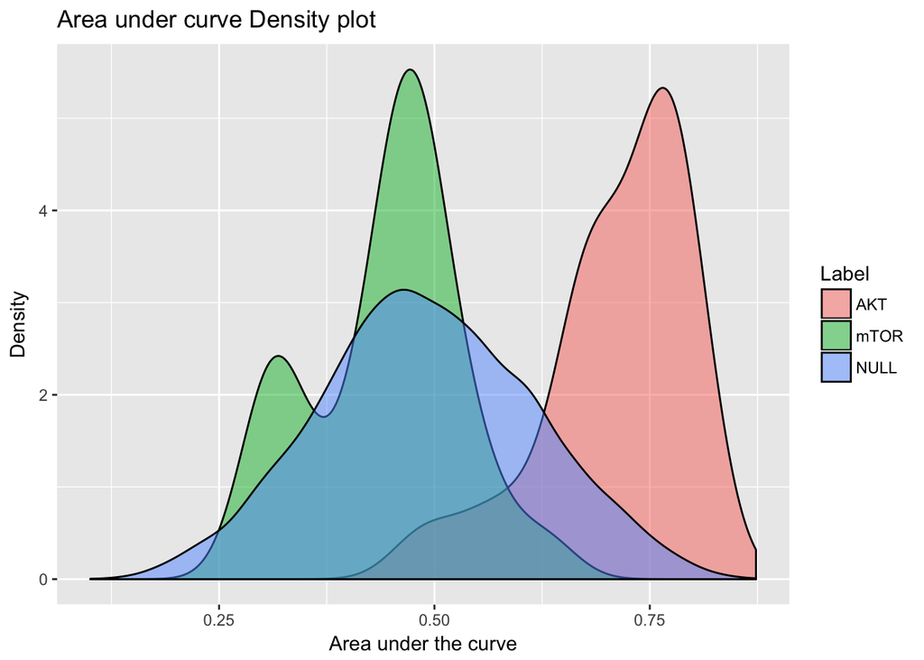

```r
##AUC density
ggplot() + geom_density(data=data, aes(x=1 - AUC, group=Label, fill=Label),alpha=0.5, adjust=1.14) + xlab("Area under the curve") + ylab("Density") + ggtitle('Area under curve Density plot')
```

### PSSM Creation and Visualisation

```r
require(Biostrings)
require(ggseqlogo)
require(ggplot2)

statData <- read.csv('~/Downloads/Final Project/Datasets/StatData.csv')

#Subset Sequences for labelled data
sequencesAKT <- statData[statData$Label == 'AKT', 5]
sequencesMTOR <- statData[statData$Label == 'mTOR', 5]

#Build PSSM for both labelled AKT and mTOR data
string_set.AKT <- AAStringSet(sequencesAKT)
PSSM.AKT <- round(consensusMatrix(string_set.AKT, as.prob = T), 5)
string_set.mTOR <- AAStringSet(sequencesMTOR)
PSSM.mTOR <- round(consensusMatrix(string_set.mTOR, as.prob = T), 5)


#Create a new column for PSSM Score AKT and mTOR
statData$PSSM_SCORE_AKT = 0
statData$PSSM_SCORE_mTOR = 0

#For each row in the data assign a PSSM score based on AKT.
for (i in 1:nrow(statData)) {
  #Set score to be 0
  score <- 0
  #Get the sequence to be testest and convert to a list of amino acids
  exampleSequence <- toString(statData[i, 5])
  exampleSequence <- list(strsplit(exampleSequence, ""))
  exampleSequence <- exampleSequence[[1]][[1]]
  #For each amino acid, sum its PSSM score
  for (j in 1:length(exampleSequence)) {
    if (exampleSequence[j] == "_") {
      next
    }
    score <- score + PSSM.AKT[exampleSequence[j], j][[1]]
  }
  statData[i , 31] = score
}

#mTOR PSSM Score
for (i in 1:nrow(statData)) {
  #Set score to be 0
  score <- 0
  #Get the sequence to be testest and convert to a list of amino acids
  exampleSequence <- toString(statData[i, 5])
  exampleSequence <- list(strsplit(exampleSequence, ""))
  exampleSequence <- exampleSequence[[1]][[1]]
  #For each amino acid, sum its PSSM score
  for (j in 1:13) {
    if (exampleSequence[j] == "_") {
      next
    }
    score <- score + PSSM.mTOR[exampleSequence[j], j][[1]]
  }
  statData[i, 32] = score
}

#Column means for AKT, mTOR and unlabelled Data.
rbind(colMeans(statData[statData$Label == 'AKT', 31:32]),
colMeans(statData[statData$Label == 'mTOR', 31:32]),
colMeans(statData[statData$Label == 'NULL', 31:32]))
```

```
##      PSSM_SCORE_AKT PSSM_SCORE_mTOR
## [1,]       4.206593        1.360126
## [2,]       1.360123        2.718922
## [3,]       1.803132        1.754417
```

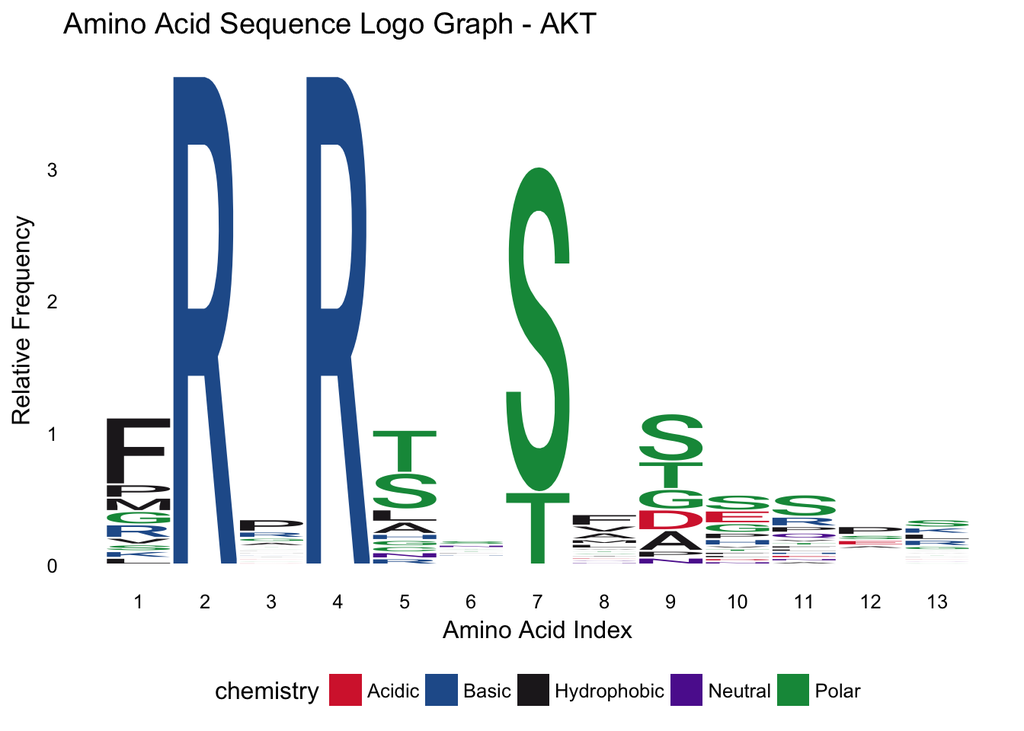

```r
#Convert dataframe column to list of strings
sequencesAKT <- sapply(sequencesAKT, toString)
sequencesMTOR <- sapply(sequencesMTOR, toString)
#Create Plots
ggseqlogo( sequencesAKT, seq_type='aa' ) + labs(title="Amino Acid Sequence Logo Graph - AKT", x ="Amino Acid Index", y = "Relative Frequency")
```

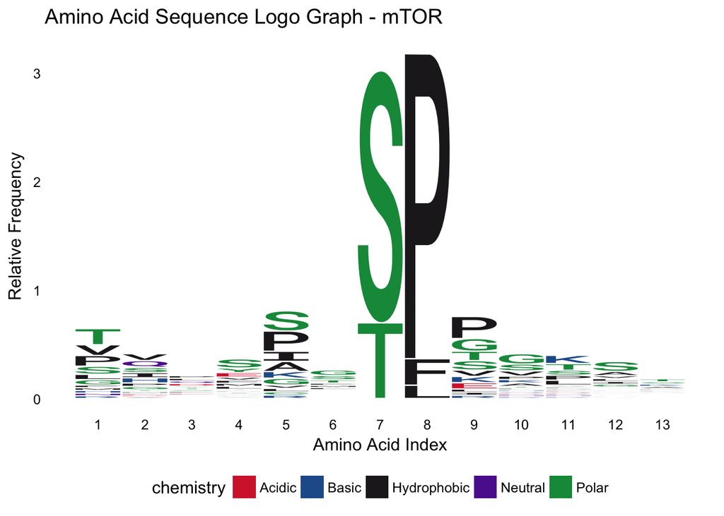

```r
ggseqlogo( sequencesMTOR, seq_type='aa' ) + labs(title="Amino Acid Sequence Logo Graph - mTOR", x ="Amino Acid Index", y = "Relative Frequency")
```

### Data cleaning, normalization and preprocessing.

```r
require(caret)
require(e1071)
set.seed(24)

#removing the centergroup field as it only has one variable
#removing other variables as there are too many levels and errors are thrown with new variables
columnsToUse <- which(colnames(data) %in% c("Label", "LeftGroup", "Center", "RightGroup"))
columnsToUse <- c(columnsToUse, 18:33)
data1 <- data[, columnsToUse]

#Here we considered averaging the two insulin values given they were repetitions of Insulin vs Basal, decided to keep them split to be more in line with PengYi's Model.
##Average INS1 and INS2
# data1$AvgIns <- rowMeans(subset(data, select = c(Ins.1, Ins.2)))
# data1 <- data1[,-c(15,17)]

#Added a similar fitting score feature from the feature creation code found on PengYi's github.
#Create fitting score
fitting.score <- c()
x <- 1:9
x2 = x^2
data1$fitted_score = 0
for (i in 1:nrow(data1)) {
  y <- as.numeric(data1[i, 7:14])
  y <- c(0, y)
  lmfit <- lm(formula = y ~ x + x2 - 1)
  data1[i,21] = summary(lmfit)$fstatistic[1]
}

##Normalise all numeric variables
data1s = data.frame(scale(data1[,5:21]))
data1ns = data1[,1:4]
data1 = cbind(data1ns, data1s)

##Dummy the categorical variables
datanl = data1[,2:21]
label = data1[,1]
dmy <- dummyVars(" ~ .", data = datanl)
datanl =data.frame(predict(dmy, newdata=datanl))
data2 = cbind(label, datanl)
```

### Create two models using positive unlabelled ensemble learning (Pengyi, 2016):

Idea is to set either AKTOR or MTOR as positive and a random sample of unlabelled data as negative and then train a model on it. We then evaluate the confidence (c) of the model. This is the probability of the model predicting a positive when the label is actually positive on the training data (i.e. train on data and then predict back on data).

We then create base classifiers using the same data and use it to predict on the total dataset and generate probabilities for positive vs. negative. The positive probability for each row is then divided by the models’s confidence value. For example, if there is 50 ensembles created then there will be 50 different positive probabilities for each row and each probability is divided by the model’s confidence. For each row this resulting value is divided by the total ensemble number. The final probabilities are found by dividing this last number by the max value of that group of numbers.

#### Create a function that returns the prediction results given a substrate, ensemble size, specific model, and kernel type.

```r
require(caret)
require(e1071)
require(glmnet)
require(xgboost)
require(gbm)
prediction <- function(trainData, substrateName, cmodel, ensembleSize, kernelType, predict.mat, polynomial = FALSE) {

  substrateData = trainData[trainData$label == substrateName,]
  notSubstrateData = trainData[trainData$label != substrateName,]

  #sampling from the negative data
  models <- list()
  estimated_c <- c()
  tot.acc <- c()

  ##Can change ensemblesize to any number based on desired number of ensembles to make
  for (r in 1:ensembleSize){
      set.seed(r)
      id <- sample(1:nrow(notSubstrateData), size = length(substrateData), replace = F)
      negative.samples <- rownames(notSubstrateData)[id]
      negative.train <- trainData[negative.samples, ]

      # classification
      x <- rbind(substrateData, negative.train)
      x <- x[,-1]
      rownames(x) <- NULL

      # estimating confidence
      if (cmodel == 'svm') {
      cls <- as.factor(rep(c(1, 2), times=c(nrow(substrateData), length(substrateData))))
      k <- 3
      fold <- createFolds(cls, k)
      svm_model <- svm(x[-fold$Fold1,], cls[-fold$Fold1], kernel=kernelType, probability=T, scale = F, degree = polynomial)

      # label 1 correspond to positive labelled examples
      p <- which(cls[fold$Fold1] == 1)
      pred <- predict(svm_model, x[fold$Fold1,][p,], decision.values=F, probability=T);
      estimated.c <- sum(attr(pred, "probabilities")[,1]) / nrow(attr(pred, "probabilities"))
      estimated_c <- c(estimated_c, estimated.c)

      # training base classifiers
      models[[r]] <- svm(x, cls, kernel=kernelType, probability=T, scale = F, degree = polynomial)
      }

      else {
      cls <- as.factor(rep(c("P", "N"), times=c(nrow(substrateData), length(substrateData))))
      k <- 3
      fold <- createFolds(cls, k)
      trnCtrl=trainControl(method='cv', number=1, returnResamp='none', summaryFunction = twoClassSummary, classProbs = TRUE)
      model=train(x[-fold$Fold1,], cls[-fold$Fold1], method=cmodel, trControl=trnCtrl,  metric = "ROC")

        # label p correspond to positive labelled examples
      p <- which(cls[fold$Fold1] == 'P')
        pred <- predict(object=model, x[fold$Fold1,][p,], type='prob')
        estimated.c <- sum(pred[,2]) / nrow(pred)
        estimated_c <- c(estimated_c, estimated.c)

    # training base classifiers
      models[[r]] <- train(x, cls, method=cmodel, trControl=trnCtrl,  metric = "ROC")

      }
    }

    ensemble.pred.corrected.100 <- 0
    ensemble.pred.corrected.250 <- 0
    ensemble.pred.corrected.500 <- 0
    ensemble.pred.corrected.750 <- 0
    ensemble.pred.corrected.1000 <- 0
    if (cmodel == 'svm') {
    for(i in 1:length(models)) {
        mod.pred <- predict(models[[i]], predict.mat, decision.values=TRUE, probability=TRUE)
        if (i <= 100) {
            ensemble.pred.corrected.100 <- ensemble.pred.corrected.100 + attr(mod.pred,"probabilities")[,1] / estimated_c[i]
        }
        if (i <= 250) {
            ensemble.pred.corrected.250 <- ensemble.pred.corrected.250 + attr(mod.pred,"probabilities")[,1] / estimated_c[i]
        }
        if (i <= 500) {
            ensemble.pred.corrected.500 <- ensemble.pred.corrected.500 + attr(mod.pred,"probabilities")[,1] / estimated_c[i]
        }
        if (i <= 750) {
            ensemble.pred.corrected.750 <- ensemble.pred.corrected.750 + attr(mod.pred,"probabilities")[,1] / estimated_c[i]
        }
        ensemble.pred.corrected.1000 <- ensemble.pred.corrected.1000 + attr(mod.pred,"probabilities")[,1] / estimated_c[i]
    }
    }
    else {
    for(i in 1:length(models)) {
        mod.pred <- predict(models[[i]], predict.mat, type = 'prob')
        if (i <= 100) {
            ensemble.pred.corrected.100 <- ensemble.pred.corrected.100 + mod.pred[,2] / estimated_c[i]
        }
        if (i <= 250) {
            ensemble.pred.corrected.250 <- ensemble.pred.corrected.250 + mod.pred[,2] / estimated_c[i]
        }
        if (i <= 500) {
            ensemble.pred.corrected.500 <- ensemble.pred.corrected.500 + mod.pred[,2] / estimated_c[i]
        }
        if (i <= 750) {
            ensemble.pred.corrected.750 <- ensemble.pred.corrected.750 + mod.pred[,2] / estimated_c[i]
        }
        ensemble.pred.corrected.1000 <- ensemble.pred.corrected.1000 + mod.pred[,2] / estimated_c[i]
    }
    }

    results <- list()
    predicts.100 <- (ensemble.pred.corrected.100 / 100)
    results$prediction_100 <- predicts.100/max(predicts.100)
    predicts.250 <- (ensemble.pred.corrected.250 / 250)
    results$prediction_250 <- predicts.250/max(predicts.250)
    predicts.500 <- (ensemble.pred.corrected.500 / 500)
    results$prediction_500 <- predicts.500/max(predicts.500)
    predicts.750 <- (ensemble.pred.corrected.750 / 750)
    results$prediction_750 <- predicts.750/max(predicts.750)
    predicts.1000 <- (ensemble.pred.corrected.1000 / 1000)
    results$prediction_1000 <- predicts.1000/max(predicts.1000)

    results$models <- models
  predictions = data.frame(results$prediction_100,results$prediction_250, results$prediction_500, results$prediction_750,     results$prediction_1000)

    return(predictions)

}
```

#### Create a function which compares predictions vs benchmark and returns the absolute difference in prediciton confidence

```r
require(readxl)
require(sqldf)

setwd('~/Downloads/Final project/')
pengYi <- read_xlsx('prediction_2016.xlsx')
pengYi_mTOR <- read_xlsx('prediction_2016.xlsx', sheet = 2)

#Rename Columns to use in SQL
colnames(pengYi)[c(2,3,6)] <- c('phosphorylation_site','sequence_window', 'full_model_predict')
colnames(pengYi_mTOR)[c(2,3,6)] <- c('phosphorylation_site','sequence_window', 'full_model_predict')

accuracy <- function(predictions, totalData, benchmark)  {

  #Join the prediction columns
  data = cbind(totalData, predictions)

  #Rename Columns to use in SQL
  colnames(data)[c(6, 34:38)] <- c('seq_window', 'prediction_100', 'prediction_250', 'prediction_500', 'prediction_750', 'prediction_1000')

  #Join PenYi's Predictions to create a Resisual Error
  joinedData <- sqldf('SELECT d.Identifier, d.GeneSymbol, d.PhosphorylationSite, d.seq_window, p.GeneSymbol, p.phosphorylation_site, p.sequence_window, p.full_model_predict, d.prediction_100, d.prediction_250, d.prediction_500, d.prediction_750, d.prediction_1000 FROM data d JOIN benchmark p ON (d.seq_window = p.sequence_window AND d.PhosphorylationSite = p.phosphorylation_site)')

  joinedData$AbsoluteDifference.100 = abs(joinedData$prediction_100 - joinedData$full_model_predict)
  joinedData$AbsoluteDifference.250 = abs(joinedData$prediction_250 - joinedData$full_model_predict)
  joinedData$AbsoluteDifference.500 = abs(joinedData$prediction_500 - joinedData$full_model_predict)
  joinedData$AbsoluteDifference.750 = abs(joinedData$prediction_750 - joinedData$full_model_predict)
  joinedData$AbsoluteDifference.1000 = abs(joinedData$prediction_1000 - joinedData$full_model_predict)

  return(joinedData)
}
```

#### Execute function prediction function for radial, polynomial and linear kernels SVM models for each Enzyme.

```r
AKTradial_predict <- prediction(trainData = data2, substrateName = "AKT", cmodel = 'svm', ensembleSize =  1000, kernelType = 'radial', predict.mat = data2[,-1])
mTORradial_predict <- prediction(trainData = data2, substrateName = "mTOR", cmodel = 'svm', ensembleSize =  1000, kernelType = 'radial', predict.mat = data2[,-1])

AKTpolynomial_predict <- prediction(trainData = data2, substrateName = "AKT", cmodel = 'svm', ensembleSize =  1000, kernelType = 'polynomial', polynomial = 3, predict.mat = data2[,-1])
mTORpolynomial_predict <- prediction(trainData = data2, substrateName = "mTOR", cmodel = 'svm', ensembleSize =  1000, kernelType = 'polynomial', polynomial = 3, predict.mat = data2[,-1])

AKTlinear_predict <- prediction(trainData = data2, substrateName = "AKT", cmodel = 'svm', ensembleSize =  1000, kernelType = 'linear', predict.mat = data2[,-1])
mTORlinear_predict <- prediction(trainData = data2, substrateName = "mTOR", cmodel = 'svm', ensembleSize =  1000, kernelType = 'linear', predict.mat = data2[,-1])
```

### Evaluate and plot the accuracy of the predictions vs the benchmark data.

```r
AKTradial_accuracy <- accuracy(predictions = AKTradial_predict, totalData = data, benchmark = pengYi)
mTORradial_accuracy <- accuracy(predictions = mTORradial_predict, totalData = data, benchmark = pengYi_mTOR)

AKTpolynomial_accuracy <- accuracy(predictions = AKTpolynomial_predict, totalData = data, benchmark = pengYi)
mTORpolynomial_accuracy <- accuracy(predictions = mTORpolynomial_predict, totalData = data, benchmark = pengYi_mTOR)

AKTlinear_accuracy <- accuracy(predictions = AKTlinear_predict, totalData = data, benchmark = pengYi)
mTORlinear_accuracy <- accuracy(predictions = mTORlinear_predict, totalData = data, benchmark = pengYi_mTOR)

plot(x = c(100, 250, 500, 750, 1000), colMeans(AKTradial_accuracy[, 14:18]), type = 'line', ylab = 'Mean Absolute difference', xlab = 'nEnsembles', col = 'red', xlim = c(100,1000), ylim = c(0.00,0.25)) + lines(x = c(100, 250, 500, 750, 1000), colMeans(AKTpolynomial_accuracy[, 14:18]), type = 'line', col = 'blue') + lines(x = c(100, 250, 500, 750, 1000), colMeans(AKTlinear_accuracy[, 14:18]), type = 'line', col = 'green') + lines(x = c(100, 250, 500, 750, 1000), colMeans(mTORradial_accuracy[, 14:18]), type = 'line', col = 'red', lty = 2)+ lines(x = c(100, 250, 500, 750, 1000), colMeans(mTORpolynomial_accuracy[, 14:18]), type = 'line', col = 'blue', lty = 2) + lines(x = c(100, 250, 500, 750, 1000), colMeans(mTORlinear_accuracy[, 14:18]), type = 'line', col = 'green', lty = 2)
```

```
## integer(0)
```

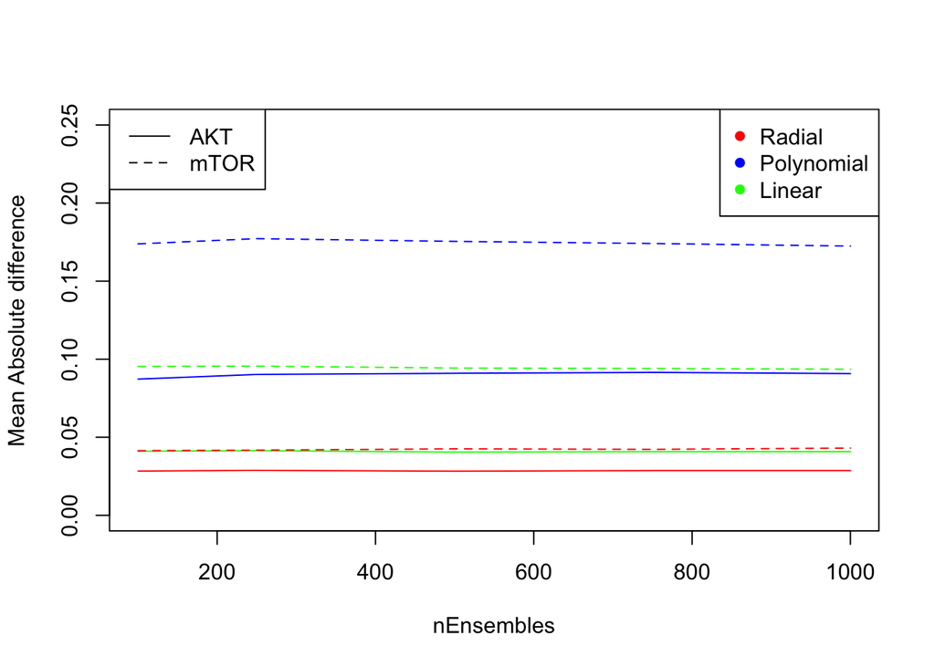

```r
legend("topright",legend=c('Radial', 'Polynomial', 'Linear'), col= c('red', 'blue', 'green'), pch = 16)
legend('topleft', legend = c('AKT', 'mTOR'), lty = c(1,2))
```

#####The above graph shows that there is not much difference in mean absolute difference as number of ensembles increase. A radial kernel does much better than linear and polynomial (degree of 3) and AKT predictions are much better than mTOR predictions. The choice was made to complete more than 50 models as we wanted each datapoint given in the raw data to be expected to be sampled, as to remove bias.

### Create the top 30 highest prediction file using radial 100 ensembles

```r
AKTrad30 = cbind(data, AKTradial_predict)
AKTrad30 = AKTrad30[,c(2:6,34)]
AKTrad30 = AKTrad30[order(-AKTrad30$results.prediction_100),]

mTORrad30 = cbind(data, mTORradial_predict)
mTORrad30 = mTORrad30[,c(2:6,34)]
mTORrad30 = mTORrad30[order(-mTORrad30$results.prediction_100),]

head(AKTrad30, 30)
```

```
##                 Identifier       GeneSymbol PhosphorylationSite Label
## 11567             TSC2;981             TSC2                 981   AKT
## 4632             FKHR2;252            FKHR2                 252   AKT
## 5155              GSK3A;21            GSK3A                  21   AKT
## 11566             TSC2;939             TSC2                 939   AKT
## 1437              AZI1;114             AZI1                 114  NULL
## 4359            FAM13A;322           FAM13A                 322  NULL
## 10295 RP24-258K7.2-001;430 RP24-258K7.2-001                 430  NULL
## 209              ABPL;2234             ABPL                2234  NULL
## 10398             RTKN;520             RTKN                 520  NULL
## 1215             AS160;324            AS160                 324   AKT
## 4705             FOXO1;316            FOXO1                 316   AKT
## 5933             KANK1;325            KANK1                 325  NULL
## 411               AF6;1802              AF6                1802  NULL
## 2009           CABLES1;272          CABLES1                 272  NULL
```

[output cut: 47 more lines]

```r
head(mTORrad30, 30)
```

```
##         Identifier GeneSymbol PhosphorylationSite Label    Seq.Window
## 9006     PATL1;184      PATL1                 184  mTOR TSPIIGSPPVRAV
## 5123     GRB10;503      GRB10                 503  mTOR NILSSQSPLHPST
## 11859    WDR91;257      WDR91                 257  NULL PASLSQSPRVGFL
## 7641       MAF1;68       MAF1                  68  mTOR PQTSGLSPSRLSK
## 7436      LIP1;444       LIP1                 444  NULL LETMGSSPLSTTK
## 11671     ULK1;450       ULK1                 450  NULL IEQNLQSPTQQQT
## 6517  KIAA0623;781   KIAA0623                 781  NULL GPGLGSSPPGAEG
## 7640       MAF1;60       MAF1                  60  mTOR HVLEALSPPQTSG
## 8923       OXR1;62       OXR1                  62  NULL RPPSPASPEGPDT
## 3647    DOPEY2;597     DOPEY2                 597  NULL IGLSASSPELSEH
## 8777     NOLZ1;107      NOLZ1                 107  NULL LPSTPVSPIELDA
## 10384      RRN3;42       RRN3                  42  NULL ESDFFNSPPKKTV
## 7513     LPIN1;323      LPIN1                 323  NULL DTFSDQSPTMARG
## 4176      ERK3;704       ERK3                 704  NULL PSAMKSSPQIPHK
```

[output cut: 47 more lines]

```r
# write.csv(AKTrad30, 'AKTradial100.csv')
# write.csv(mTORrad30, 'mTORradial100.csv')
```

```r
#Radial
AKTradial_predict50 <- prediction(trainData = data2, substrateName = "AKT", cmodel = 'svm', ensembleSize =  50, kernelType = 'radial', predict.mat = data2[,-1])
mTORradial_predict50 <- prediction(trainData = data2, substrateName = "mTOR", cmodel = 'svm', ensembleSize =  50, kernelType = 'radial', predict.mat = data2[,-1])

#Poly6
AKTpolynomial_predict50 <- prediction(trainData = data2, substrateName = "AKT", cmodel = 'svm', ensembleSize =  50, kernelType = 'polynomial', polynomial = 3, predict.mat = data2[,-1])
mTORpolynomial_predict50 <- prediction(trainData = data2, substrateName = "mTOR", cmodel = 'svm', ensembleSize =  50, kernelType = 'polynomial', polynomial = 3, predict.mat = data2[,-1])

#Linear
AKTlinear_predict50 <- prediction(trainData = data2, substrateName = "AKT", cmodel = 'svm', ensembleSize =  50, kernelType = 'linear', predict.mat = data2[,-1])
mTORlinear_predict50 <- prediction(trainData = data2, substrateName = "mTOR", cmodel = 'svm', ensembleSize =  50, kernelType = 'linear', predict.mat = data2[,-1])

#RF
AKTrf_predict50 <- prediction(trainData = data2, substrateName = "AKT", cmodel = 'rf', ensembleSize =  50, kernelType = 'linear', predict.mat = data2[,-1])
mTORrf_predict50 <- prediction(trainData = data2, substrateName = "mTOR", cmodel = 'rf', ensembleSize =  50, kernelType = 'linear', predict.mat = data2[,-1])

#xgbtree
AKTxgb_predict50 <- prediction(trainData = data2, substrateName = "AKT", cmodel = 'xgbTree', ensembleSize =  50, kernelType = 'xgbTree', predict.mat = data2[,-1])
mTORxgb_predict50 <- prediction(trainData = data2, substrateName = "mTOR", cmodel = 'xgbTree', ensembleSize =  50, kernelType = 'xgbTree', predict.mat = data2[,-1])

#glmnet
AKTglm_predict50 <- prediction(trainData = data2, substrateName = "AKT", cmodel = 'glmnet', ensembleSize =  50, kernelType = 'linear', predict.mat = data2[,-1])
mTORglm_predict50 <- prediction(trainData = data2, substrateName = "mTOR", cmodel = 'glmnet', ensembleSize =  50, kernelType = 'linear', predict.mat = data2[,-1])

#gbm
# AKTgbm_predict50 <- prediction(trainData = data2, substrateName = "AKT", cmodel = 'gbm', ensembleSize =  50, kernelType = 'linear', predict.mat = data2[,-1])
# mTORgbm_predict50 <- prediction(trainData = data2, substrateName = "mTOR", cmodel = 'gbm', ensembleSize =  50, kernelType = 'linear', predict.mat = data2[,-1])

##Accuracies
AKTradial_accuracy50 <- accuracy(predictions = AKTradial_predict50, totalData = data, benchmark = pengYi)
mTORradial_accuracy50 <- accuracy(predictions = mTORradial_predict50, totalData = data, benchmark = pengYi_mTOR)

AKTpolynomial_accuracy50 <- accuracy(predictions = AKTpolynomial_predict50, totalData = data, benchmark = pengYi)
mTORpolynomial_accuracy50 <- accuracy(predictions = mTORpolynomial_predict50, totalData = data, benchmark = pengYi_mTOR)

AKTlinear_accuracy50 <- accuracy(predictions = AKTlinear_predict50, totalData = data, benchmark = pengYi)
mTORlinear_accuracy50 <- accuracy(predictions = mTORlinear_predict50, totalData = data, benchmark = pengYi_mTOR)

AKTrf_accuracy50 <- accuracy(predictions = AKTrf_predict50, totalData = data, benchmark = pengYi)
mTORrf_accuracy50 <- accuracy(predictions = mTORrf_predict50, totalData = data, benchmark = pengYi_mTOR)

AKTxgb_accuracy50 <- accuracy(predictions = AKTxgb_predict50, totalData = data, benchmark = pengYi)
mTORxgb_accuracy50 <- accuracy(predictions = mTORxgb_predict50, totalData = data, benchmark = pengYi_mTOR)

AKTglm_accuracy50 <- accuracy(predictions = AKTglm_predict50, totalData = data, benchmark = pengYi)
mTORglm_accuracy50 <- accuracy(predictions = mTORglm_predict50, totalData = data, benchmark = pengYi_mTOR)

# AKTgbm_accuracy50 <- accuracy(predictions = AKTgbm_predict50, totalData = data, benchmark = pengYi)
# mTORgbm_accuracy50 <- accuracy(predictions = mTORgbm_predict50, totalData = data, benchmark = pengYi_mTOR)

alin = mean(AKTlinear_accuracy50$AbsoluteDifference.100)
apoly = mean(AKTpolynomial_accuracy50$AbsoluteDifference.100)
arad = mean(AKTradial_accuracy50$AbsoluteDifference.100)
arf = mean(AKTrf_accuracy50$AbsoluteDifference.100)
axgb = mean(AKTxgb_accuracy50$AbsoluteDifference.100)
aglm = mean(AKTglm_accuracy50$AbsoluteDifference.100)

aktad = cbind(alin, apoly, arad, arf, axgb, aglm)
colnames(aktad) = c('Linear', 'Poly3', 'Radial', 'RandomForest', 'XgbTree', 'GLMnet')
rownames(aktad) = c('AKT')

mlin = mean(mTORlinear_accuracy50$AbsoluteDifference.100)
mpoly = mean(mTORpolynomial_accuracy50$AbsoluteDifference.100)
mrad = mean(mTORradial_accuracy50$AbsoluteDifference.100)
mrf = mean(mTORrf_accuracy50$AbsoluteDifference.100)
mxgb = mean(mTORxgb_accuracy50$AbsoluteDifference.100)
mglm = mean(mTORglm_accuracy50$AbsoluteDifference.100)

mtorad = cbind(mlin, mpoly, mrad, mrf, mxgb, mglm)
colnames(mtorad) = c('Linear', 'Poly3', 'Radial', 'RandomForest', 'XgbTree', 'GLMnet')
rownames(mtorad) = c('mTOR')

absolutediff = rbind(aktad, mtorad)
absolutediff
```

```
##          Linear     Poly3     Radial RandomForest    XgbTree     GLMnet
## AKT  0.04175277 0.0883147 0.02869639   0.03804053 0.05612627 0.03671777
## mTOR 0.09338062 0.1716812 0.04095772   0.07231333 0.10359418 0.08820743
```

### Generate Synthetic data to analyze the behavior of the model

```r
#install.packages('mlbench')
require(mlbench)
```

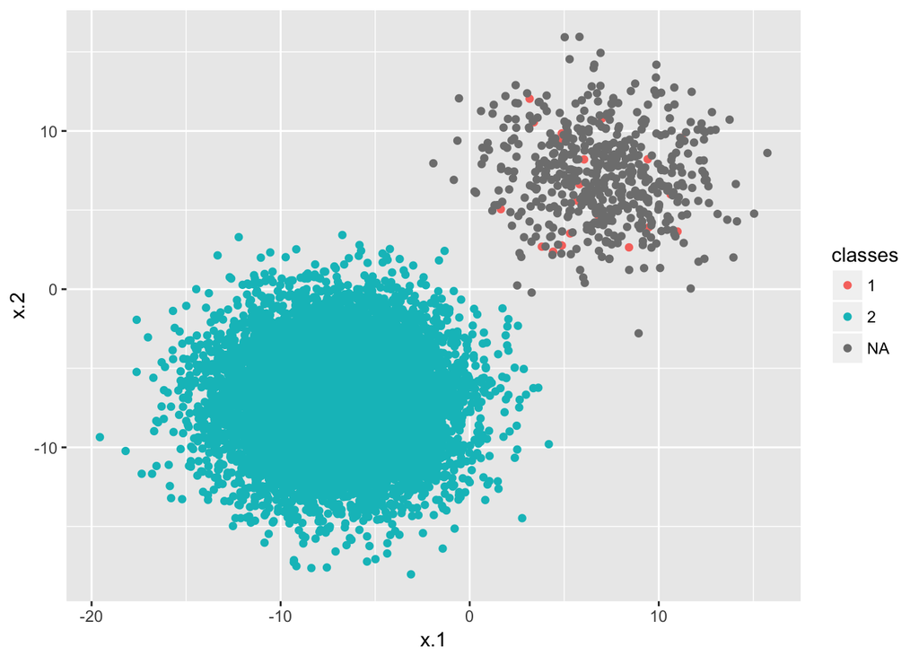

```r
require(dplyr)
# a fucntion to make a Sythetic classification data from 2 dimensional Gaussian
makeSyData<-function(num_labeled_pos, num_unlabeled_pos, num_neg){
  SyData<-as.data.frame(mlbench.2dnormals(num_neg*2, 2, r=10, sd=3))
  SyData.positive<-sample_n(SyData[SyData['classes']==1,], size=num_labeled_pos+num_unlabeled_pos, replace = F)
  rownames(SyData.positive)<-NULL
  #unlabel 500 points
  SyData.positive[seq(num_labeled_pos+1,num_labeled_pos+num_unlabeled_pos),'classes']<-NA
  SyData.negative<-SyData[SyData['classes']==2,]
  SyData<-rbind(SyData.positive, SyData.negative)
  rownames(SyData)<-NULL
  SyData
  #plot(SyData)
}
#make sythetic data set
SyData<-makeSyData(20, 500, 10000)
qplot(x.1, x.2, colour = classes , data = SyData)
```

```r
#prepare the sysnetic data set for training (change all negatives and unlabeled positive to 2)
trainData=SyData
unlabel_id<-which(trainData['classes']!=1)
trainData$classes[is.na(trainData$classes)]<-2
predictData<-trainData[trainData['classes']!=1,][,-3]
```

### Create updated function for synthetic data

```r
SyPrediction <- function(trainData, ensembleSize, cmodel, kernelType, predict.mat, polynomial = FALSE) {

  positiveData = trainData[trainData$classes == 1,]
  notPositiveData = trainData[trainData$classes!=1,]

  #sampling from the negative data
  models <- list()
  estimated_c <- c()
  tot.acc <- c()

  ##Can change ensemblesize to any number based on desired number of ensembles to make
  for (r in 1:ensembleSize){
      set.seed(r)
      id <- sample(1:nrow(notPositiveData), size = length(positiveData), replace = F)
      negative.samples <- rownames(notPositiveData)[id]
      negative.train <- trainData[negative.samples, ]

      # classification
      x <- rbind(positiveData, negative.train)
      x <- x[,-1]
      rownames(x) <- NULL

      # estimating confidence
      if (cmodel == 'svm') {
      cls <- as.factor(rep(c(1, 2), times=c(nrow(positiveData), length(positiveData))))
      k <- 3
      fold <- createFolds(cls, k)
      svm_model <- svm(x[-fold$Fold1,], cls[-fold$Fold1], kernel=kernelType, probability=T, scale = F, degree = polynomial)

      # label 1 correspond to positive labelled examples
      p <- which(cls[fold$Fold1] == 1)
      pred <- predict(svm_model, x[fold$Fold1,][p,], decision.values=F, probability=T);
      estimated.c <- sum(attr(pred, "probabilities")[,1]) / nrow(attr(pred, "probabilities"))
      estimated_c <- c(estimated_c, estimated.c)

      # training base classifiers
      models[[r]] <- svm(x, cls, kernel=kernelType, probability=T, scale = F, degree = polynomial)
      }

      else {
      cls <- as.factor(rep(c("P", "N"), times=c(nrow(positiveData), length(positiveData))))
      k <- 3
      fold <- createFolds(cls, k)
      trnCtrl=trainControl(method='cv', number=1, returnResamp='none', summaryFunction = twoClassSummary, classProbs = TRUE)
      model=train(x[-fold$Fold1,], cls[-fold$Fold1], method=cmodel, trControl=trnCtrl,  metric = "ROC")

        # label p correspond to positive labelled examples
      p <- which(cls[fold$Fold1] == 'P')
        pred <- predict(object=model, x[fold$Fold1,][p,], type='prob')
        estimated.c <- sum(pred[,2]) / nrow(pred)
        estimated_c <- c(estimated_c, estimated.c)

    # training base classifiers
      models[[r]] <- train(x, cls, method=cmodel, trControl=trnCtrl,  metric = "ROC")

      }
    }

    ensemble.pred.corrected.100 <- 0
    ensemble.pred.corrected.250 <- 0
    ensemble.pred.corrected.500 <- 0
    ensemble.pred.corrected.750 <- 0
    ensemble.pred.corrected.1000 <- 0
    if (cmodel == 'svm') {
    for(i in 1:length(models)) {
        mod.pred <- predict(models[[i]], predict.mat, decision.values=TRUE, probability=TRUE)
        if (i <= 100) {
            ensemble.pred.corrected.100 <- ensemble.pred.corrected.100 + attr(mod.pred,"probabilities")[,1] / estimated_c[i]
        }
        if (i <= 250) {
            ensemble.pred.corrected.250 <- ensemble.pred.corrected.250 + attr(mod.pred,"probabilities")[,1] / estimated_c[i]
        }
        if (i <= 500) {
            ensemble.pred.corrected.500 <- ensemble.pred.corrected.500 + attr(mod.pred,"probabilities")[,1] / estimated_c[i]
        }
        if (i <= 750) {
            ensemble.pred.corrected.750 <- ensemble.pred.corrected.750 + attr(mod.pred,"probabilities")[,1] / estimated_c[i]
        }
        ensemble.pred.corrected.1000 <- ensemble.pred.corrected.1000 + attr(mod.pred,"probabilities")[,1] / estimated_c[i]
    }
    }
    else {
    for(i in 1:length(models)) {
        mod.pred <- predict(models[[i]], predict.mat, type = 'prob')
        if (i <= 100) {
            ensemble.pred.corrected.100 <- ensemble.pred.corrected.100 + mod.pred[,2] / estimated_c[i]
        }
        if (i <= 250) {
            ensemble.pred.corrected.250 <- ensemble.pred.corrected.250 + mod.pred[,2] / estimated_c[i]
        }
        if (i <= 500) {
            ensemble.pred.corrected.500 <- ensemble.pred.corrected.500 + mod.pred[,2] / estimated_c[i]
        }
        if (i <= 750) {
            ensemble.pred.corrected.750 <- ensemble.pred.corrected.750 + mod.pred[,2] / estimated_c[i]
        }
        ensemble.pred.corrected.1000 <- ensemble.pred.corrected.1000 + mod.pred[,2] / estimated_c[i]
    }
    }

    results <- list()
    predicts.100 <- (ensemble.pred.corrected.100 / 100)
    results$prediction_100 <- predicts.100/max(predicts.100)
    predicts.250 <- (ensemble.pred.corrected.250 / 250)
    results$prediction_250 <- predicts.250/max(predicts.250)
    predicts.500 <- (ensemble.pred.corrected.500 / 500)
    results$prediction_500 <- predicts.500/max(predicts.500)
    predicts.750 <- (ensemble.pred.corrected.750 / 750)
    results$prediction_750 <- predicts.750/max(predicts.750)
    predicts.1000 <- (ensemble.pred.corrected.1000 / 1000)
    results$prediction_1000 <- predicts.1000/max(predicts.1000)

    results$models <- models
  predictions = data.frame(results$prediction_100,results$prediction_250, results$prediction_500, results$prediction_750,     results$prediction_1000)

    return(predictions)

}
```

### Test the model on the Synthetic data (50 ensembles)

```r
SyPredictions<- SyPrediction(trainData, 50, 'svm', 'linear', predictData, polynomial = FALSE)

#get prediction probabilities
SyPred_pro<-SyPredictions[,5]
#get the labelling result from the probabilites
# >0.5 then 1, <=0.5 then 2
SyPred_label<-c()
for (pro in SyPred_pro){
  if(pro>0.5){label=1}
  if(pro<=0.5){label=2}
  SyPred_label<-c(SyPred_label, label)
}
#get the gold labeling
SyGold<-rep(c(1,2), c(500, length(SyPred_pro)-500))
#a function to calculate the evaluation metrics
calculate_metrics<-function(SyGold, SyPred_label){
  TP=TN=FP=FN=0
  for(i in 1:length(SyGold)){
    if(SyPred_label[i]==1){
      #TP
      if(SyGold[i]==1){
        TP=TP+1}
      #FP
      if(SyGold[i]==2){
        FP=FP+1
      }
    }

    if(SyPred_label[i]==2){
      #TN
      if(SyGold[i]==2){
        TN=TN+1}
      #FN
      if(SyGold[i]==1){
        FN=FN+1
      }
    }
  }
  #Accuracy
  acc=(TP+TN)/(TP+TN+FP+FN)
  #Sensitivity
  se=TP/(TP+FN)
  #Specificity
  sp=TN/(FP+TN)
  #F1
  f1=2*TP/(2*TP+FP+FN)
  #GM
  GM=sqrt((TP/(TP+FN))*(TP/(TP+FP)))
  #MCC
  MCC=(TP*TN-FP*FN)/sqrt((TP+FP)*(TP+FN)*(TN+FP)*(TN+FN))
  return(c(acc, se, sp, f1, GM, MCC))
}
#evaluation metrics
metrics<-as.data.frame(calculate_metrics(SyGold, SyPred_label))
rownames(metrics)<-c('acc', 'se', 'sp', 'f1', 'GM', 'MCC')
colnames(metrics)<-c('Corrected Ensemble')
metrics
```

```
##     Corrected Ensemble
## acc          0.7189854
## se           0.9980000
## sp           0.7050165
## f1           0.2529785
## GM           0.3802077
## MCC          0.3189521
```

##### Our PUEL model has a high sensitivity (predicts most actual positive as positive) but has lower specificity. This is because it seems to try and predict more points as positive.

### Function to do AdaSampling with a Single SVM model

```r
###A function to calculate probabilites differences
pro_diff<-function(pre_pros, this_pros){
  n=length(pre_pros)
  pd<-sum(abs(pre_pros-this_pros))/n
  return(pd)
}

###a function to do adaSampling iteration with a single SVM model
#parameters:
#LP: labeled positives
#LN: labeled negatives
#UL: unlabeled data, last(initial) prediction probabilities is stored
#pre_pros:last prediction probabilities for all the points
require(dplyr)
adaSingleIter<-function(iter, threshold, LP, LN, UL, pre_pros){

  #replace positive label as 1
  LP$label<-1
  #replace negative label as 2
  LN$label<-2
  #choose negative points from ULabel probabilites
  sorted_UL<-UL[with(UL, order(pros)), ]
  negative.samples<-sorted_UL[1:20,]
  #label negative samples
  negative.samples$label<-2

  #prepare trainning data
  train.mat<-rbind(LP, LN, subset(negative.samples, select=-c(pros)))
  All.mat<-rbind(LP, LN, subset(UL, select=-c(pros)))
  #train a simple SVM model
  #tune the class weight due to imbalance
  svm_model <- svm(train.mat[,-1], y=as.factor(train.mat[,1]), class.weights=c('1'=2,'2'=1), probability=T, scale=F)
  #get this prediction probabilities for all instances
  pred <- predict(svm_model, All.mat[,-1], decision.values=F, probability=T)
  this_pros <- attr(pred, "probabilities")[,1]
  #add the unlabel probabilities to the data frame
  UL['pros']=attr(predict(svm_model, subset(UL, select=-c(pros))[,-1], decision.values=F, probability=T), "probabilities")[,1]

  #calculate probabilities difference
  pd<-pro_diff(pre_pros, this_pros)

  #while iter > 10000
  while(pd > threshold){
    pre_pros<-this_pros
    #choose negative points from ULabel probabilites
    sorted_UL<-UL[with(UL, order(pros)), ]
    negative.samples<-sorted_UL[1:25,]
    #label negative samples
    negative.samples$label<-2

    #prepare trainning data
    train.mat<-rbind(LP, LN, subset(negative.samples, select=-c(pros)))
    #train a simple SVM model
    #tune the class weight due to imbalance
    svm_model <- svm(train.mat[,-1], y=as.factor(train.mat[,1]), class.weights=c('1'=2,'2'=1), probability=T,     scale=F)
    #get this prediction probabilities for all instances
    pred <- predict(svm_model, All.mat[,-1], decision.values=F, probability=T)
    this_pros <- attr(pred, "probabilities")[,1]
    #add the unlabel probabilities to the data frame
    UL['pros']=attr(predict(svm_model, subset(UL, select=-c(pros))[,-1], decision.values=F, probability=T),      "probabilities")[,1]

    #calculate probabilities difference
    pd<-pro_diff(pre_pros, this_pros)
    #an iteration
    # iter=iter+1
    # print(iter)
    # print(pd)

  }

  #otherwise the probabilities difference reach the threshold, return UL
  #Prediction dataset
  predict.mat <- data2[,-1]
  pred <- predict(svm_model, predict.mat, decision.values=F, probability=T)
  return_pros <- data.frame(attr(pred, "probabilities")[,1])
  #print(UL['pros'])
  return(return_pros)
}


###A function to wrap adaSingleIter for initializing adaSampling
adaSampling<-function(iter, threshold, LP, LN, UL){
  #initialize the process by random sampling the negative points
  #replace positive label as 1
  LP$label<-1
  #replace negative label as 2
  LN$label<-2
  #choose negative points by random sampling
  negative.samples<-sample_n(UL, size=nrow(LP), replace=F)
  #label negative samples
  negative.samples$label<-2
  #prepare trainning data

  train.mat<-rbind(LP, LN, negative.samples)
  All.mat<-rbind(LP, LN, UL)
  #train a simple SVM model
  #tune the class weight due to imbalance
  svm_model <- svm(x=as.matrix(train.mat[,-1]), y=as.factor(train.mat[,1]), class.weights=c('1'=3,'2'=1),    probability=T, scale=F)
  #get this prediction probabilities for all instances
  pred <- predict(svm_model, All.mat[,-1], decision.values=F, probability=T)
  this_pros <- attr(pred, "probabilities")[,1]
  #add the unlabel probabilities to the data frame
  UL['pros']=attr(predict(svm_model, UL[,-1], decision.values=F, probability=T), "probabilities")[,1]
  predictions_result<-adaSingleIter(iter, threshold, LP, LN, UL, this_pros)
  predictions_result

}

#LP=AKTdata
#LN=MTORdata
#UL=NAkMtdata
```

### AdaSampling to predict AKT and MTOR

```r
###Prepare the data set
#AKT Data
AKTdata = data2[data2$label == 'AKT',]
NAKTdata = data2[data2$label != 'AKT',]
#MTORdata
MTORdata = data2[data2$label == 'mTOR',]
NMTORdata = data2[data2$label != 'mTOR',]
#unlabelled data
NAkMtdata = data2[data2$label == 'NULL',]
#Ada Sampling for Akt
predictions_result<- adaSampling(0, 0.0001, AKTdata, MTORdata, NAkMtdata)
predictions_result_mTor<-adaSampling(0, 0.0001, MTORdata, AKTdata, NAkMtdata)
```

### Compare AdaSampling result with 2016 Predictions

```r
library(readxl)
library(sqldf)

#setwd('~/Downloads/Final project/')
#AKT 2016 Predictions
# pengYi <- read_xlsx('/Users/carolchen/Desktop/STAT5003Assignment2/Final Project/Final project/prediction_2016.xlsx')
# #mTOR 2016 Predictions
# pengYi_mTOR <- read_xlsx('/Users/carolchen/Desktop/STAT5003Assignment2/Final Project/Final project/prediction_2016.xlsx', sheet = 2)

#Join the prediction columns
data3 = cbind(data, predictions_result, predictions_result_mTor)

#Rename Columns to use in SQL
# colnames(pengYi)[c(2,3,6)] <- c('phosphorylation_site','sequence_window', 'full_model_predict')
# colnames(pengYi_mTOR)[c(2,3,6)] <- c('phosphorylation_site','sequence_window', 'full_model_predict')
colnames(data3)[c(6, 34, 35)] <- c('seq_window', 'prediction_Akt', 'prediction_Mtor')

#Join PenYi's Predictions to create a Resisual Error
joinedData <- sqldf('SELECT d.Identifier, d.GeneSymbol, d.PhosphorylationSite, d.seq_window, p.GeneSymbol, p.phosphorylation_site, p.sequence_window, p.full_model_predict, d.prediction_Akt FROM data3 d JOIN pengYi p ON (d.seq_window = p.sequence_window AND d.PhosphorylationSite = p.phosphorylation_site)')

joinedData$AbsoluteDifference = abs(joinedData$prediction_Akt - joinedData$full_model_predict)
print(mean(joinedData$AbsoluteDifference))
```

```
## [1] 0.1101433
```

```r
#Join the prediction columns
joinedData_mTOR <- sqldf('SELECT d.Identifier, d.GeneSymbol, d.PhosphorylationSite, d.seq_window, p.GeneSymbol, p.phosphorylation_site, p.sequence_window, p.full_model_predict, d.prediction_Mtor
                         FROM data3 d JOIN pengYi_mTOR p
                         ON (d.seq_window = p.sequence_window AND d.PhosphorylationSite = p.phosphorylation_site)')

joinedData_mTOR$AbsoluteDifference = abs(joinedData_mTOR$prediction_Mtor-joinedData_mTOR$full_model_predict)
print(mean(joinedData_mTOR$AbsoluteDifference))
```

```
## [1] 0.4329028
```

### Top30 predictions from ADA

```r
AKTada30 = cbind(data, predictions_result)
AKTada30 = AKTada30[,c(2:6,34)]
AKTada30 = AKTada30[order(-AKTada30[,6]),]

mTORada30 = cbind(data, predictions_result_mTor)
mTORada30 = mTORada30[,c(2:6,34)]
mTORada30 = mTORada30[order(-mTORada30[,6]),]

head(AKTada30, 30)
```

```
##                 Identifier       GeneSymbol PhosphorylationSite Label
## 4632             FKHR2;252            FKHR2                 252   AKT
## 11567             TSC2;981             TSC2                 981   AKT
## 5155              GSK3A;21            GSK3A                  21   AKT
## 1437              AZI1;114             AZI1                 114  NULL
## 10295 RP24-258K7.2-001;430 RP24-258K7.2-001                 430  NULL
## 209              ABPL;2234             ABPL                2234  NULL
## 4359            FAM13A;322           FAM13A                 322  NULL
## 10398             RTKN;520             RTKN                 520  NULL
## 1215             AS160;324            AS160                 324   AKT
## 11566             TSC2;939             TSC2                 939   AKT
## 411               AF6;1802              AF6                1802  NULL
## 4705             FOXO1;316            FOXO1                 316   AKT
## 2009           CABLES1;272          CABLES1                 272  NULL
## 3760            ECNOS;1176            ECNOS                1176   AKT
```

[output cut: 47 more lines]

```r
head(mTORada30, 30)
```

```
##          Identifier GeneSymbol PhosphorylationSite Label    Seq.Window
## 3931    EIF4EBP1;64   EIF4EBP1                  64  mTOR LMECRNSPVAKTP
## 8777      NOLZ1;107      NOLZ1                 107  NULL LPSTPVSPIELDA
## 6517   KIAA0623;781   KIAA0623                 781  NULL GPGLGSSPPGAEG
## 9006      PATL1;184      PATL1                 184  mTOR TSPIIGSPPVRAV
## 5123      GRB10;503      GRB10                 503  mTOR NILSSQSPLHPST
## 9406    PLEKHM1;404    PLEKHM1                 404  NULL SDQQPSSPVGGAA
## 1273       ATBP;505       ATBP                 505  NULL SAIPFQSPRNSGS
## 11859     WDR91;257      WDR91                 257  NULL PASLSQSPRVGFL
## 10419    SAMD4B;271     SAMD4B                 271  NULL PDHAPLSPQSSVA
## 3254          DAP;3        DAP                   3  NULL ____MSSPPEGKL
## 3647     DOPEY2;597     DOPEY2                 597  NULL IGLSASSPELSEH
## 2411      CDK14;126      CDK14                 126  NULL SPSSPTSPKFGKA
## 4176       ERK3;704       ERK3                 704  NULL PSAMKSSPQIPHK
## 11108  TBC1D10B;664   TBC1D10B                 664  NULL AVGGAPSPPPPVR
```

[output cut: 47 more lines]

```r
# write.csv(AKTada30, 'AKTada.csv')
# write.csv(mTORada30, 'mTORada.csv')
```

### Test adaSampling on Synthetic data

```r
###A function to calculate probabilites differences
pro_diff<-function(pre_pros, this_pros){
  n=length(pre_pros)
  pd<-sum(abs(pre_pros-this_pros))/n
  return(pd)

}

###a function to do adaSampling on Synthetic data
require(dplyr)
SyadaSingleIter<-function(iter, threshold, LP, LN, UL, pre_pros){

  #replace positive label as 1
  LP['label']<-1
  #replace negative label as 2
  LN['label']<-2
  #choose negative points from ULabel probabilites
  sorted_UL<-UL[with(UL, order(pros)), ]
  #sample 20 negative points
  negative.samples<-sorted_UL[1:20,]

  #prepare trainning data
  train.mat<-rbind(LP, LN, subset(negative.samples, select=-c(pros)))
  All.mat<-rbind(LP, LN, subset(UL, select=-c(pros)))
  #train a simple SVM model
  #tune the class weight due to imbalance
  svm_model <- svm(train.mat[,-3], y=as.factor(train.mat[,3]), class.weights=c('1'=2,'2'=1), probability=T, scale=F)
  #get this prediction probabilities for all instances
  pred <- predict(svm_model, All.mat[,-3], decision.values=F, probability=T)
  this_pros <- attr(pred, "probabilities")[,1]
  #add the unlabel probabilities to the data frame
  UL['pros']=attr(predict(svm_model, subset(UL, select=-c(pros))[,-3], decision.values=F, probability=T), "probabilities")[,1]

  #calculate probabilities difference
  pd<-pro_diff(pre_pros, this_pros)

  #while pd > threshold
  while(pd>threshold){
    pre_pros<-this_pros
    #choose negative points from ULabel probabilites
    sorted_UL<-UL[with(UL, order(pros)), ]
    #get top 20
    negative.samples<-sorted_UL[1:20,]
    #label negative samples
    negative.samples$label<-2

    #prepare trainning data
    train.mat<-rbind(LP, LN, subset(negative.samples, select=-c(pros)))
    #train a simple SVM model
    #tune the class weight due to imbalance
    svm_model <- svm(train.mat[,-3], y=as.factor(train.mat[,3]), class.weights=c('1'=2,'2'=1), probability=T,     scale=F)
    #get this prediction probabilities for all instances
    pred <- predict(svm_model, All.mat[,-3], decision.values=F, probability=T)
    this_pros <- attr(pred, "probabilities")[,1]
    #add the unlabel probabilities to the data frame
    UL['pros']=attr(predict(svm_model, subset(UL, select=-c(pros))[,-3], decision.values=F, probability=T),      "probabilities")[,1]

    #calculate probabilities difference
    pd<-pro_diff(pre_pros, this_pros)
    #an iteration
    # iter=iter+1
    # print(iter)
    # print(pd)

  }

  return(this_pros)
}

###A function to wrap adaSingleIter for initializing adaSampling
SyadaSampling<-function(iter, threshold, LP, LN, UL){
  #initialize the process by random sampling the negative points
  #replace positive label as 1
  LP['label']<-1
  #replace negative label as 2
  LN['label']<-2
  UL['label']<-2
  #choose negative points by random sampling
  negative.samples<-sample_n(UL, size=nrow(LP), replace=F)
  #prepare trainning data
  train.mat<-rbind(LP, LN, negative.samples)
  #all the unlabel data
  All.mat<-rbind(LP, LN, UL)

  #train a simple SVM model
  #tune the class weight due to imbalance
  svm_model <- svm(x=as.matrix(train.mat[,-3]), y=as.factor(train.mat[,3]), class.weights=c('1'=3,'2'=1),    probability=T, scale=F)
  #get this prediction probabilities for all instances
  pred <- predict(svm_model, All.mat[,-3], decision.values=F, probability=T)
  this_pros <- attr(pred, "probabilities")[,1]
  #add the unlabel probabilities to the data frame
  UL['pros']=attr(predict(svm_model, UL[,-3], decision.values=F, probability=T), "probabilities")[,1]
  predictions_result<-SyadaSingleIter(iter, threshold, LP, LN, UL, this_pros)
  predictions_result

}

#prepare data
LP=SyData[1:20,-3]
LN=SyData[521:540,-3]
UL=rbind(SyData[21:520,-3],SyData[541:nrow(SyData),-3])

SyAdaPredictions<-SyadaSampling(0, 0.001, LP, LN, UL)

#evaluation
SyAdaGold<-rep(c(1,2), c(500, length(SyAdaPredictions)-500))
SyAdaPred_label<-c()
for (pro in SyAdaPredictions){
  if(pro>0.5){label=1}
  if(pro<=0.5){label=2}
  SyAdaPred_label<-c(SyAdaPred_label, label)
}

#evaluation metrics
ada_metrics<-as.data.frame(calculate_metrics(SyAdaGold, SyAdaPred_label))
rownames(ada_metrics)<-c('acc', 'se', 'sp', 'f1', 'GM', 'MCC')
#ada_metrics
metrics<-cbind(metrics, ada_metrics)
colnames(metrics)<-c('Corrected Ensemble', 'AdaSampling')
metrics
```

```
##     Corrected Ensemble AdaSampling
## acc          0.7189854   0.8698011
## se           0.9980000   0.9600000
## sp           0.7050165   0.8652943
## f1           0.2529785   0.4123711
## GM           0.3802077   0.5020745
## MCC          0.3189521   0.4634713
```